# Clase 3. Pasajeros y otras características del Metro en la CDMX

Benjamin Oliva

01/04/2025

# Importamos Datos:

Los datos importados son:

- Pasajeros_Millones: Pasajeros transportados (Millones) en el Metro de la CDMX
- TrenesEnServicio_Unidades: Trenes que están en servicio (Unidades) en el Metro de la CDMX
- KilometrosRedEnServicio: Kilómetros de red en servicio en el Metro de la CDMX
- KilometrosRecorridos_Miles: Kilómetros recorridos en el sistema del Metro de la CDMX

Fuente: INEGI, https://www.inegi.org.mx/app/indicadores/?tm=0#D668903

```r
Datos <- read_excel("Base_Transporte.xlsx", sheet = "Datos", col_names = TRUE)

Fecha = as.Date(Datos$Periodo, format = "%d/%m/%Y")

head(Datos)
```

```
## # A tibble: 6 × 5
##   Periodo             Pasajeros_Millones TrenesEnServicio_Unidades
##   <dttm>                           <dbl>                     <dbl>
## 1 2000-01-01 00:00:00               112.                       259
## 2 2000-02-01 00:00:00               112.                       258
## 3 2000-03-01 00:00:00               121.                       261
## 4 2000-04-01 00:00:00               106.                       261
## 5 2000-05-01 00:00:00               118.                       266
## 6 2000-06-01 00:00:00               118.                       268
## # ℹ 2 more variables: KilometrosRedEnServicio <dbl>,
## #   KilometrosRecorridos_Miles <dbl>
```

# Repaso de manejo de Data Frames:

```r
#View(Datos)

names(Datos)
```

```
## [1] "Periodo"                    "Pasajeros_Millones"
## [3] "TrenesEnServicio_Unidades"  "KilometrosRedEnServicio"
## [5] "KilometrosRecorridos_Miles"
```

```r
tail(Datos)
```

```
## # A tibble: 6 × 5
##   Periodo             Pasajeros_Millones TrenesEnServicio_Unidades
##   <dttm>                           <dbl>                     <dbl>
## 1 2024-08-01 00:00:00              101.                        240
## 2 2024-09-01 00:00:00               99.8                       256
## 3 2024-10-01 00:00:00              110.                        256
## 4 2024-11-01 00:00:00              103.                        256
## 5 2024-12-01 00:00:00               99.0                       256
## 6 2025-01-01 00:00:00               96.6                       256
## # ℹ 2 more variables: KilometrosRedEnServicio <dbl>,
## #   KilometrosRecorridos_Miles <dbl>
```

```r
str(Datos)
```

```
## tibble [301 × 5] (S3: tbl_df/tbl/data.frame)
##  $ Periodo                   : POSIXct[1:301], format: "2000-01-01" "2000-02-01" ...
##  $ Pasajeros_Millones        : num [1:301] 112 112 121 106 118 ...
##  $ TrenesEnServicio_Unidades : num [1:301] 259 258 261 261 266 268 268 270 266 264 ...
##  $ KilometrosRedEnServicio   : num [1:301] 191 191 190 190 190 190 190 190 190 190 ...
##  $ KilometrosRecorridos_Miles: num [1:301] 3258 3074 3308 3045 3277 ...
```

```r
dim(Datos)
```

```
## [1] 301   5
```

```r
Datos[ , 2]
```

```
## # A tibble: 301 × 1
##    Pasajeros_Millones
##                 <dbl>
##  1               112.
##  2               112.
##  3               121.
##  4               106.
##  5               118.
##  6               118.
##  7               115.
##  8               122.
##  9               117.
## 10               122.
## # ℹ 291 more rows
```

```r
Datos[5 , ]
```

```
## # A tibble: 1 × 5
##   Periodo             Pasajeros_Millones TrenesEnServicio_Unidades
##   <dttm>                           <dbl>                     <dbl>
## 1 2000-05-01 00:00:00               118.                       266
## # ℹ 2 more variables: KilometrosRedEnServicio <dbl>,
## #   KilometrosRecorridos_Miles <dbl>
```

```r
Datos[c(2:259) , 2]
```

```
## # A tibble: 258 × 1
##    Pasajeros_Millones
##                 <dbl>
##  1               112.
##  2               121.
##  3               106.
##  4               118.
##  5               118.
##  6               115.
##  7               122.
##  8               117.
##  9               122.
## 10               115.
## # ℹ 248 more rows
```

```r
Datos[ , c(2:5)]
```

```
## # A tibble: 301 × 4
##    Pasajeros_Millones TrenesEnServicio_Unidades KilometrosRedEnServicio
##                 <dbl>                     <dbl>                   <dbl>
##  1               112.                       259                     191
##  2               112.                       258                     191
##  3               121.                       261                     190
##  4               106.                       261                     190
##  5               118.                       266                     190
##  6               118.                       268                     190
##  7               115.                       268                     190
##  8               122.                       270                     190
##  9               117.                       266                     190
## 10               122.                       264                     190
## # ℹ 291 more rows
## # ℹ 1 more variable: KilometrosRecorridos_Miles <dbl>
```

```r
Datos[ , c(2, 3, 4, 5)]
```

```
## # A tibble: 301 × 4
##    Pasajeros_Millones TrenesEnServicio_Unidades KilometrosRedEnServicio
##                 <dbl>                     <dbl>                   <dbl>
##  1               112.                       259                     191
##  2               112.                       258                     191
##  3               121.                       261                     190
##  4               106.                       261                     190
##  5               118.                       266                     190
##  6               118.                       268                     190
##  7               115.                       268                     190
##  8               122.                       270                     190
##  9               117.                       266                     190
## 10               122.                       264                     190
## # ℹ 291 more rows
## # ℹ 1 more variable: KilometrosRecorridos_Miles <dbl>
```

```r
Datos[c("Pasajeros_Millones", "TrenesEnServicio_Unidades")]
```

```
## # A tibble: 301 × 2
##    Pasajeros_Millones TrenesEnServicio_Unidades
##                 <dbl>                     <dbl>
##  1               112.                       259
##  2               112.                       258
##  3               121.                       261
##  4               106.                       261
##  5               118.                       266
##  6               118.                       268
##  7               115.                       268
##  8               122.                       270
##  9               117.                       266
## 10               122.                       264
## # ℹ 291 more rows
```

# Tabla de estadísticas decriptivas

```r
summary( Datos[ ,c(2:5)] )
```

```
##  Pasajeros_Millones TrenesEnServicio_Unidades KilometrosRedEnServicio
##  Min.   : 35.9      Min.   :196.0             Min.   :187.0
##  1st Qu.:111.0      1st Qu.:256.0             1st Qu.:201.0
##  Median :120.1      Median :272.0             Median :201.0
##  Mean   :116.3      Mean   :263.4             Mean   :208.1
##  3rd Qu.:130.0      3rd Qu.:278.0             3rd Qu.:226.0
##  Max.   :154.7      Max.   :299.0             Max.   :226.0
##  KilometrosRecorridos_Miles
##  Min.   :2487
##  1st Qu.:3193
##  Median :3370
##  Mean   :3389
##  3rd Qu.:3604
##  Max.   :4018
```

```r
#Resumen1 <- summary(Datos[ ,c(2:5)])

#Resumen1
```

# Graficas:

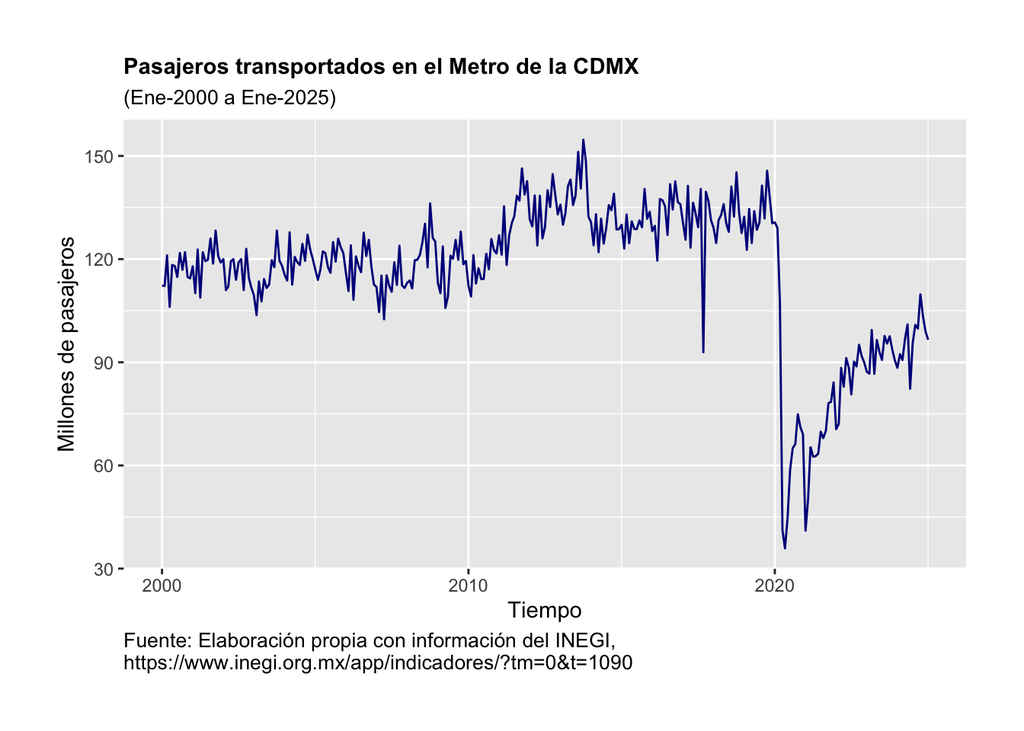

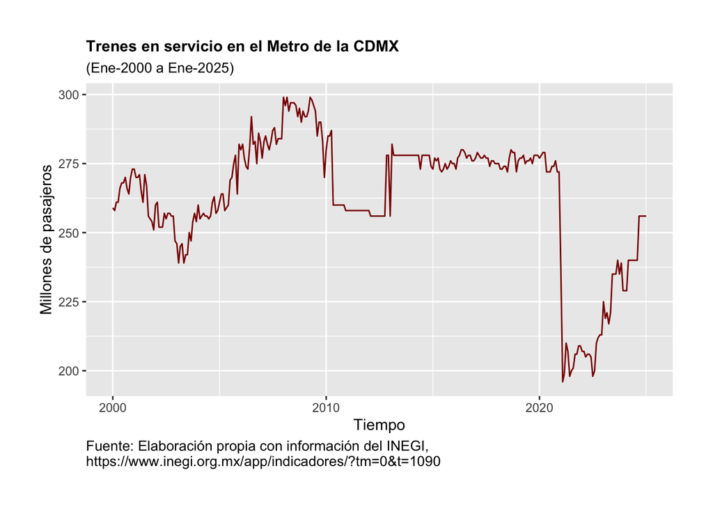

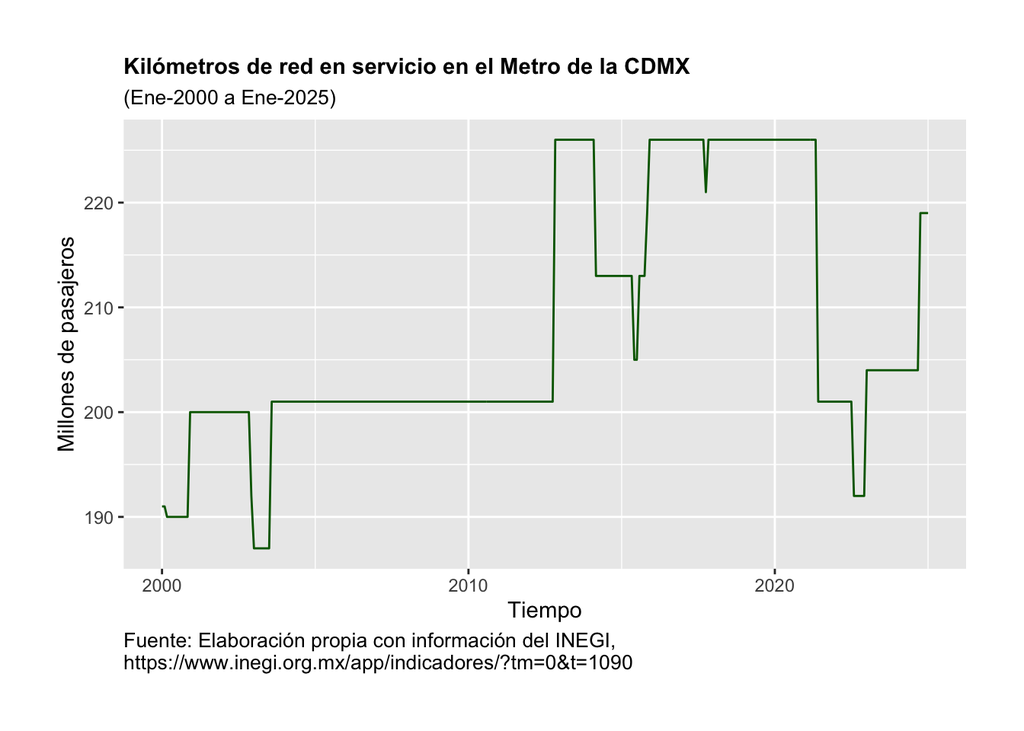

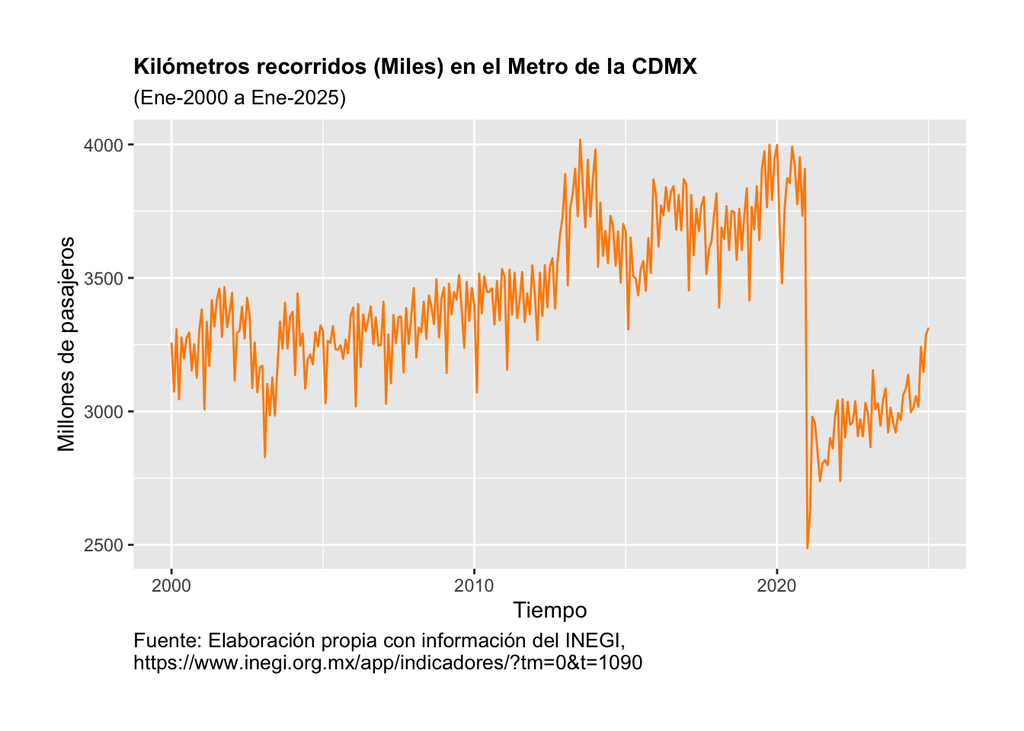

### Creamos una nueva variable: Pasajeros por kilómetro recorrido

```r
Datos$Pax_Km <- Datos$Pasajeros_Millones / (Datos$KilometrosRecorridos_Miles/1000)
```

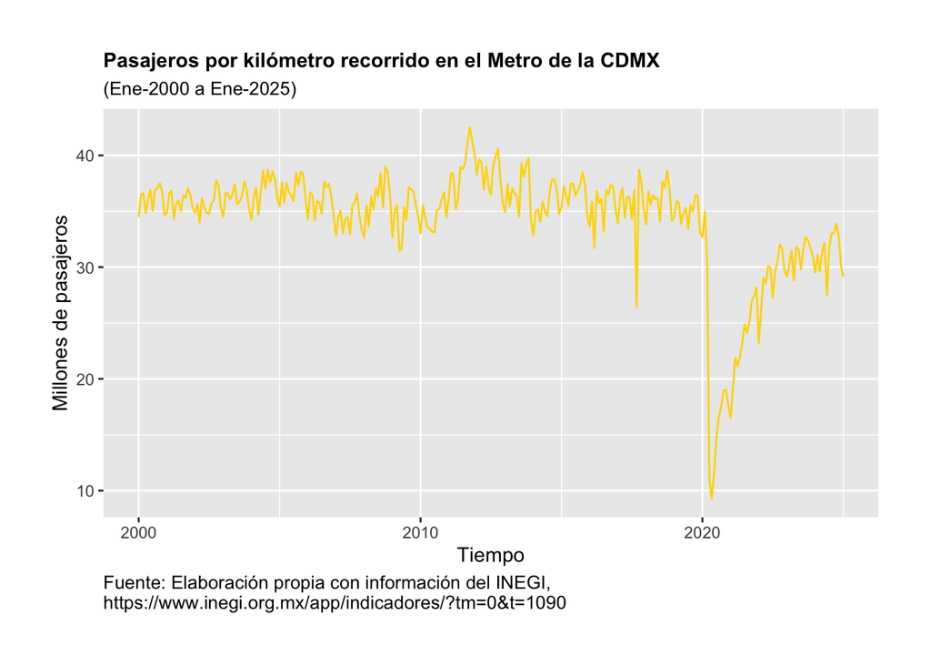

# Tabla de estadisticas de caracterización de los kilómetros recorridos (Miles) en el Metro de la CDMX

## Tres períodos:

1. Antes de la línea 12 (Fecha de Inauguración: 30 de octubre de 2012)

```r
Linea12 <- subset(Datos, Fecha <= as.Date("01/10/2012", format = "%d/%m/%Y"))

dim(Linea12)
```

```
## [1] 154   6
```

2. Después de la línea 12 (Fecha de Inauguración: 30 de octubre de 2012) y antes de la pandemía de Covid-19 (enero de 2020)

```r
PreCovid19 <- subset(Datos, Fecha > as.Date("01/10/2012", format = "%d/%m/%Y") & Fecha <= as.Date("01/01/2020", format = "%d/%m/%Y") )

dim(PreCovid19)
```

```
## [1] 87  6
```

3. Post pandemía de Covid-19 (enero de 2020)

```r
PostCovid19 <- subset(Datos, Fecha > as.Date("01/01/2020", format = "%d/%m/%Y") )

dim(PostCovid19)
```

```
## [1] 60  6
```

## Tabla de estadisticas de caracterización de los tres data sets

```r
Tabla_Pax_Metro <- data.frame(matrix( c( "Media", "Varianza", "n" ),
                                      nrow = 3, ncol = 1) )

#
names(Tabla_Pax_Metro) <- c("Estadistica")

Tabla_Pax_Metro
```

```
##   Estadistica
## 1       Media
## 2    Varianza
## 3           n
```

```r
Tabla_Pax_Metro$M_01 <- 0

Tabla_Pax_Metro$M_02 <- 0

Tabla_Pax_Metro$M_03 <- 0

Tabla_Pax_Metro
```

```
##   Estadistica M_01 M_02 M_03
## 1       Media    0    0    0
## 2    Varianza    0    0    0
## 3           n    0    0    0
```

## Llenado de la tabla:

```r
# Medias
Tabla_Pax_Metro[1, 2] <- round(mean(Linea12$KilometrosRecorridos_Miles), digits = 2)
Tabla_Pax_Metro[1, 3] <- round(mean(PreCovid19$KilometrosRecorridos_Miles), digits = 2)
Tabla_Pax_Metro[1, 4] <- round(mean(PostCovid19$KilometrosRecorridos_Miles), digits = 2)
# Varianzas muestrales
Tabla_Pax_Metro[2, 2] <- round(sum( ( Linea12$KilometrosRecorridos_Miles - mean(Linea12$KilometrosRecorridos_Miles) )^2) / (length(Linea12$KilometrosRecorridos_Miles) - 1), digits = 2)
Tabla_Pax_Metro[2, 3] <- round(sum( ( PreCovid19$KilometrosRecorridos_Miles - mean(PreCovid19$KilometrosRecorridos_Miles) )^2) / (length(PreCovid19$KilometrosRecorridos_Miles) - 1), digits = 2)
Tabla_Pax_Metro[2, 4] <- round(sum( ( PostCovid19$KilometrosRecorridos_Miles - mean(PostCovid19$KilometrosRecorridos_Miles) )^2) / (length(PostCovid19$KilometrosRecorridos_Miles) - 1), digits = 2)
#
Tabla_Pax_Metro[3, 2] <- length(Linea12$KilometrosRecorridos_Miles)
Tabla_Pax_Metro[3, 3] <- length(PreCovid19$KilometrosRecorridos_Miles)
Tabla_Pax_Metro[3, 4] <- length(PostCovid19$KilometrosRecorridos_Miles)
#
Tabla_Pax_Metro
```

```
##   Estadistica     M_01     M_02      M_03
## 1       Media  3311.10  3709.75   3125.34
## 2    Varianza 19833.18 23422.87 129648.37
## 3           n   154.00    87.00     60.00
```

## Pruebas de Hipótesis:

$$\begin{eqnarray}
H_0 & : & \mu_1 - \mu_2 = \delta \nonumber \\
H_a & : & \mu_1 - \mu_2 \neq \delta
\end{eqnarray}$$

Para lo cual hay que probar primero:
$$\begin{eqnarray}
H_0 & : & \sigma^2_1 = \sigma^2_2 \nonumber \\
H_a & : & \sigma^2_1 \neq \sigma^2_2
\end{eqnarray}$$

Por que necesitamos construir una transformación para todo para de muestras:
$$\begin{eqnarray*}
F & = & \frac{ \hat{\sigma}^2_2 \sigma^2_1 }{
\hat{\sigma}^2_1 \sigma^2_2 } \sim f_{[n_1 - 1, n_2 - 1]} \\
& & \text{que bajo $H_0$:} \\
& = & \frac{ \hat{\sigma}^2_2 }{ \hat{\sigma}^2_1 }
\end{eqnarray*}$$

De acuerdo con la tabla de F de Fisher, tenemos que:
$$\begin{eqnarray*}
f_{[\alpha/2, n_1 - 1, n_2 - 1]} & & \text{para el límite
superior} \\
f_{[1 - \alpha/2, n_1 - 1, n_2 - 1]} & = &
\frac{1}{f_{[\alpha/2, n_2 - 1, n_1 - 1]}} \\
& & \text{para el límite inferior}
\end{eqnarray*}$$

Después tendremos que, con los datos proporcionados, calcular:
$$\begin{equation*}
\hat{\sigma}_p = \sqrt{ \frac{ (n_1 - 1)\hat{\sigma}^2_1 + (n_2 -
1)\hat{\sigma}^2_2 }{n_1 + n_2 - 2} }
\end{equation*}$$

Por lo tanto, requerimos calcular:
$$\begin{equation*}
T = \frac{ (\overline{X}_1 - \overline{X}_2) - (\mu_1 - \mu_2) }{
\hat{\sigma}_p \sqrt{ \frac{1}{n_1} + \frac{1}{n_2} } }
\end{equation*}$$

Y determinar el estadístico $t_{\alpha, n_1 + n_2 -2}$ de tablas para límite superior y como límite inferior $-t_{\alpha, n_1 + n_2 -2}$.

## Comparación entre el período el pre-Covid19 y pre-línea 12

```r
F_PreCovid19_Linea12 <- Tabla_Pax_Metro[2, 3] / Tabla_Pax_Metro[2, 2]

IC <- c( 1 / qf(p = 0.975, df1 = Tabla_Pax_Metro[3, 2] - 1, df2 = Tabla_Pax_Metro[3, 3] - 1,
                lower.tail = TRUE),
         qf( p = 0.975, df1 = Tabla_Pax_Metro[3, 3] - 1, df2 = Tabla_Pax_Metro[3, 2] - 1,
             lower.tail = TRUE) )

paste0( F_PreCovid19_Linea12, " está dentro del intervalo:", "(", IC[1], ",", IC[2], ")", sep = " " )
```

```
## [1] "1.18099417239192 está dentro del intervalo:(0.680028193541318,1.44140010252739) "
```

```r
Sigma_p_PreCovid19_Linea12 <- sqrt( ( (Tabla_Pax_Metro[3, 3] - 1)*(Tabla_Pax_Metro[2, 3]) + (Tabla_Pax_Metro[3, 2] - 1)*(Tabla_Pax_Metro[2, 2]) ) / (Tabla_Pax_Metro[3, 3] + Tabla_Pax_Metro[3, 2] - 2) )

T_PreCovid19_Linea12 <- (Tabla_Pax_Metro[1, 3] - Tabla_Pax_Metro[1, 2]) / ( Sigma_p_PreCovid19_Linea12 * sqrt((1/Tabla_Pax_Metro[3, 3]) + (1 / Tabla_Pax_Metro[3, 2])) )

IC <- c( - qt( p = 0.975, df = Tabla_Pax_Metro[3, 3] + Tabla_Pax_Metro[3, 2] - 2, lower.tail = TRUE),
         qt( p = 0.975, df = Tabla_Pax_Metro[3, 3] + Tabla_Pax_Metro[3, 2] - 2, lower.tail = TRUE) )

paste0( T_PreCovid19_Linea12, " está fuera del intervalo:", "(", IC[1], ",", IC[2], ")", sep = " " )
```

```
## [1] "20.450608550275 está fuera del intervalo:(-1.96993940591696,1.96993940591696) "
```

## Comparación entre el período post-Covid19 y el pre-Covid19

```r
F_PostCovid19_PreCovid19 <- Tabla_Pax_Metro[2, 4] / Tabla_Pax_Metro[2, 3]

IC <- c( 1 / qf(p = 0.975, df1 = Tabla_Pax_Metro[3, 3] - 1, df2 = Tabla_Pax_Metro[3, 4] - 1,
                lower.tail = TRUE),
         qf( p = 0.975, df1 = Tabla_Pax_Metro[3, 4] - 1, df2 = Tabla_Pax_Metro[3, 3] - 1,
             lower.tail = TRUE) )

paste0( F_PostCovid19_PreCovid19, " está fuera del intervalo:", "(", IC[1], ",", IC[2], ")", sep = " " )
```

```
## [1] "5.53511888167419 está fuera del intervalo:(0.616924088527539,1.58723898864565) "
```

# Tarea 1:

Elabore un reporte que incluya:

1. Una breve discusión de cómo abordará el problema planteado.
2. Las pruebas estadísticas que considere necesarias.
3. Una conclusión.

Fecha de entrega: 11 de abril de 2025.